# Part 1

Shuwen Zhang

Template file. Code will be included in folded blocks in the output to facilitate grading. Please knit this file and commit both the rmd and the html output. If you add external files to your analysis, please commit them to the files folder in this repository. NOTE: please do not commit large (15MB+) files to GitHub. Instead please denote the origin of the files in your code.

Section A: Conduct an exploratory data analysis of homes in Detroit. Offer an overview of relevant trends in the data and data quality issues. Contextualize your analysis with key literature on properties in Detroit.

1. Sales Data

```
##   parcel_num          sale_date            sale_price         grantor
##  Length:276550      Min.   :2011-01-01   Min.   :       0   Length:276550
##  Class :character   1st Qu.:2013-12-18   1st Qu.:       1   Class :character
##  Mode  :character   Median :2015-10-12   Median :    1500   Mode  :character
##                     Mean   :2015-11-09   Mean   :   22924
##                     3rd Qu.:2018-01-03   3rd Qu.:   18000
##                     Max.   :2020-11-05   Max.   :13000000
##    grantee           sale_terms            ecf              property_c
##  Length:276550      Length:276550      Length:276550      Min.   :401.0
##  Class :character   Class :character   Class :character   1st Qu.:401.0
##  Mode  :character   Mode  :character   Mode  :character   Median :401.0
##                                                           Mean   :402.7
##                                                           3rd Qu.:401.0
##                                                           Max.   :483.0
##    sale_year
##  Min.   :2011
##  1st Qu.:2013
##  Median :2015
##  Mean   :2015
##  3rd Qu.:2018
##  Max.   :2020
```

```
## [1] 1414
```

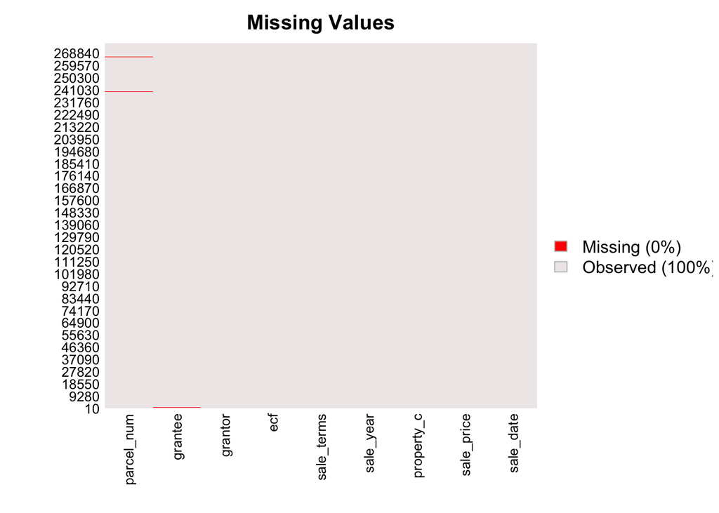

```
##
## Correlation method: 'pearson'
## Missing treated using: 'pairwise.complete.obs'
```

| term | property_c | sale_price | sale_year |
| --- | --- | --- | --- |
| property_c |  |  |  |
| sale_price | .00 |  |  |
| sale_year | -.07 | .05 |  |

Check the total number of sales by month

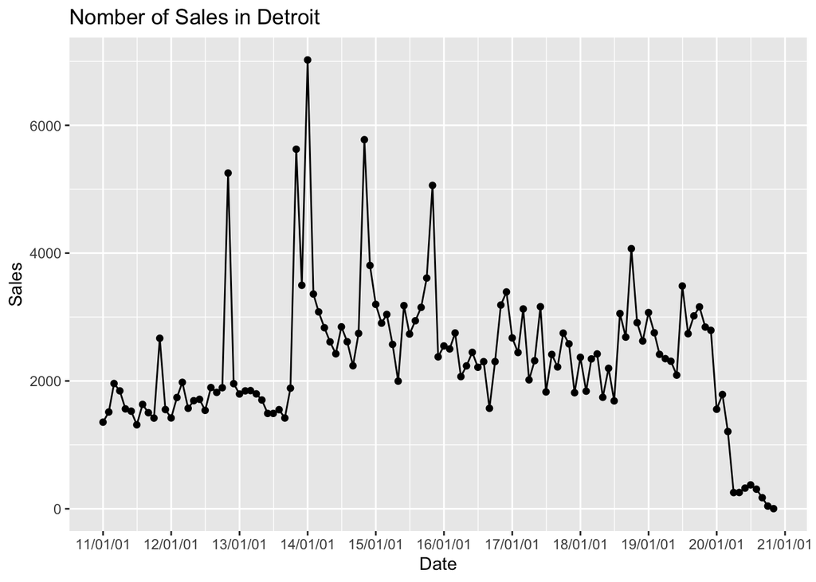

Check the average sale price by month

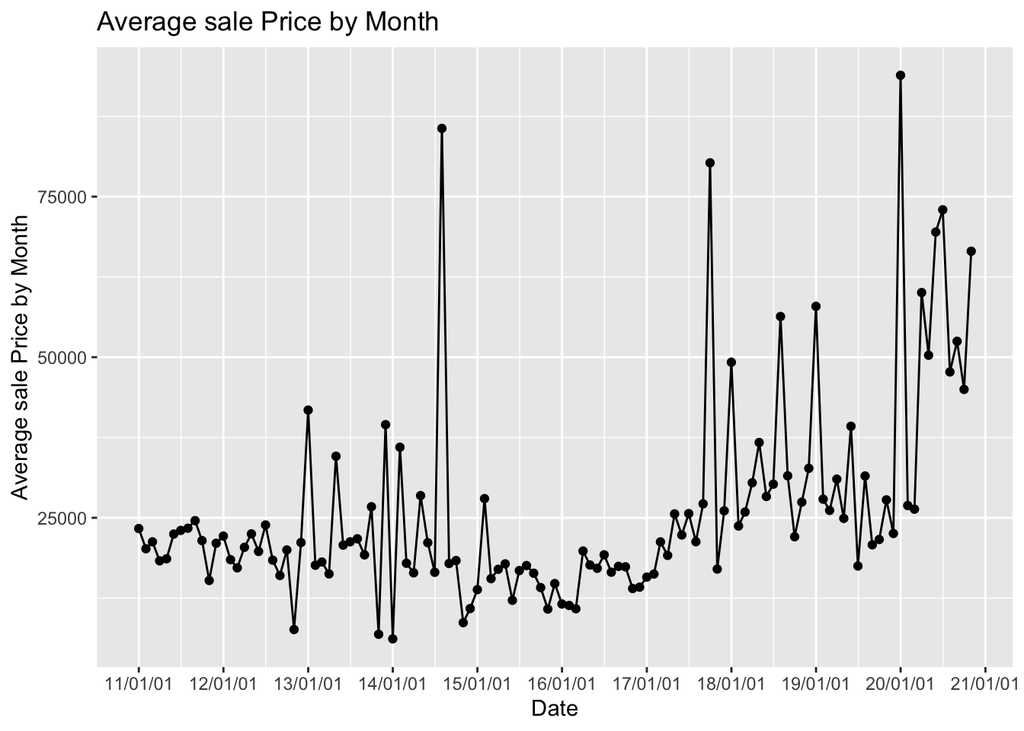

2. Blight Violation Notices Data

```
## Rows: 541,391
## Columns: 27
## $ ticket_id                  <chr> "18645", "18646", "18648", "18649", "18650"…
## $ ticket_number              <chr> "05001700DAH", "05001701DAH", "05001703DAH"…
## $ agency_name                <chr> "Buildings, Safety Engineering & Env Depart…
## $ violator_name              <chr> "Dean  Byrd", "Cynthia Roberts", "Dannny Ba…
## $ violation_street_number    <chr> "601", "607", "4066", "3005", "4024", "4017…
## $ violation_street_name      <chr> "KING", "KING", "COLUMBUS", "PASADENA", "CL…
## $ violation_zip_code         <chr> NA, NA, NA, NA, NA, NA, NA, NA, NA, NA, NA,…
## $ violator_id                <chr> "1614", "1615", "1617", "1618", "1619", "16…
## $ mailing_address_str_number <chr> "599", "18604", "4066", "3005", "20211", "1…
## $ mailing_address_str_name   <chr> "King", "Appoline", "Columbus", "Pasada", "…
## $ city                       <chr> "Det", "Det", "Det", "Det", "Det", "DEt", "…
## $ state                      <chr> "MI", "MI", "MI", "MI", "MI", "MI", "MI", "…
## $ zip_code                   <chr> "48202", "48235", "48204", "48238", "48219"…
## $ non_us_str_code            <chr> NA, NA, NA, NA, NA, NA, NA, NA, NA, NA, NA,…
## $ country                    <chr> NA, NA, NA, NA, NA, NA, NA, NA, NA, NA, NA,…
## $ violation_date             <chr> "2005/01/13 00:00:00+00", "2005/01/14 00:00…
## $ ticket_issued_time         <chr> "1900/01/01 14:00:00", "1900/01/01 00:45:00…
## $ violation_code             <chr> "9-1-36(a)", "9-1-36(a)", "9-1-36(a)", "9-1…
## $ violation_description      <chr> "Failure of owner to obtain certificate of …
## $ disposition                <chr> "Responsible by Default", "Not responsible …
## $ clean_up_cost              <chr> NA, NA, NA, NA, NA, NA, NA, NA, NA, NA, NA,…
## $ payment_amount             <chr> NA, NA, NA, NA, NA, NA, NA, NA, NA, NA, NA,…
## $ payment_date               <chr> NA, NA, NA, NA, NA, NA, NA, "2005/02/22 08:…
## $ payment_status             <chr> NA, "NO PAYMENT DUE", "NO PAYMENT DUE", "NO…
## $ collection_status          <chr> NA, NA, NA, NA, NA, NA, NA, NA, NA, NA, NA,…
## $ violation_address          <chr> "601 KING", "607 KING", "4066 COLUMBUS", "3…
## $ parcelno                   <chr> "03002390.", NA, "14002572.", NA, "14005602…
```

```
##    parcelno         violation_date     violation_code        state
##  Length:119         Length:119         Length:119         Length:119
##  Class :character   Class :character   Class :character   Class :character
##  Mode  :character   Mode  :character   Mode  :character   Mode  :character
##
##
##
##      city                year
##  Length:119         Min.   :2005
##  Class :character   1st Qu.:2005
##  Mode  :character   Median :2005
##                     Mean   :2006
##                     3rd Qu.:2005
##                     Max.   :2020
```

```
## [1] 18
```

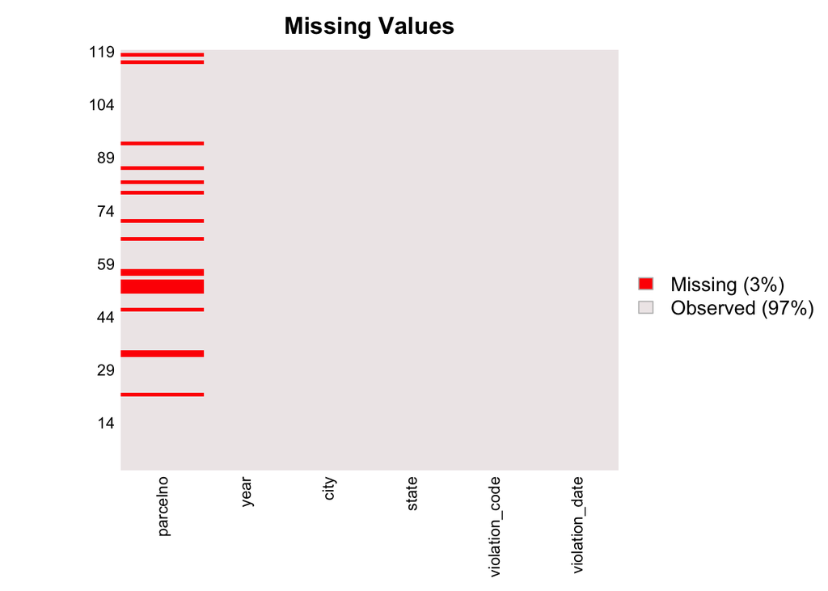

Plot violation by year

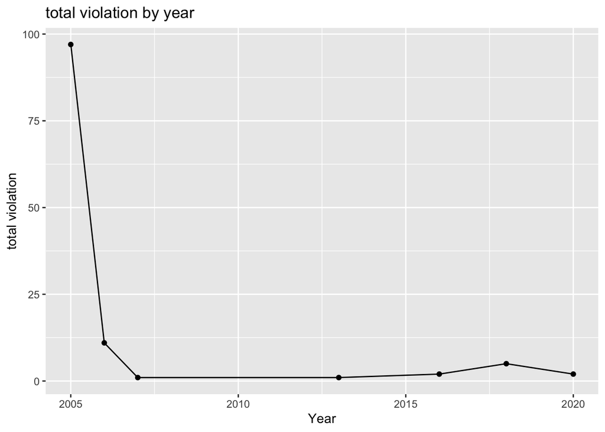

3. Parcel Data

```
## Rows: 381,265
## Columns: 41
## $ OBJECTID             <int> 1, 2, 3, 4, 5, 6, 7, 8, 9, 10, 11, 12, 13, 14, 15…
## $ object_id            <int> 77483, 77500, 77523, 77533, 77555, 77562, 77574, …
## $ parcel_number        <chr> "06004253.", "22038234.", "22034773.", "22030567-…
## $ ward                 <chr> "06", "22", "22", "22", "22", "22", "22", "22", "…
## $ address              <chr> "1699 KENDALL", "17555 STRATHMOOR", "17592 ARDMOR…
## $ council_district     <chr> "2", "2", "2", "2", "2", "2", "2", "2", "2", "2",…
## $ zip_code             <chr> "48238", "48235", "48235", "48235", "48235", "482…
## $ taxpayer_1           <chr> "DETROIT LAND BANK AUTHORITY", "JONES, DONNA", "G…
## $ taxpayer_2           <chr> NA, NA, NA, NA, NA, NA, NA, NA, NA, NA, NA, NA, N…
## $ taxpayer_street      <chr> "500 GRISWOLD STREET, SUITE 1200", "17555 STRATHM…
## $ taxpayer_city        <chr> "DETROIT", "DETROIT", "DETROIT", "DETROIT", "LIVO…
## $ taxpayer_state       <chr> "MI", "MI", "MI", "MI", "MI", "MI", "MI", "MI", "…
## $ taxpayer_zip         <chr> "48226", "48235", "48235-2603", "48235-2633", "48…
```

[output cut: 28 more lines]

```
##  parcel_number      total_square_footage total_floor_area     style
##  Length:381265      Min.   :       0     Min.   :      0   Length:381265
##  Class :character   1st Qu.:    3485     1st Qu.:    971   Class :character
##  Mode  :character   Median :    4312     Median :   1203   Mode  :character
##                     Mean   :    7103     Mean   :   2808
##                     3rd Qu.:    5232     3rd Qu.:   1619
##                     Max.   :25658756     Max.   :6112830
##                     NA's   :79           NA's   :143664
##  property_class_desc   year_built       sale_price          sale_date
##  Length:381265       Min.   :   0     Min.   :        0   Min.   :-1.857e+09
##  Class :character    1st Qu.:1925     1st Qu.:        0   1st Qu.: 5.521e+08
##  Mode  :character    Median :1939     Median :    10500   Median : 1.059e+09
##                      Mean   :1933     Mean   :    42154   Mean   : 9.282e+08
##                      3rd Qu.:1949     3rd Qu.:    30500   3rd Qu.: 1.305e+09
##                      Max.   :2107     Max.   :195000000   Max.   : 1.629e+09
##                      NA's   :143664                       NA's   :100182
##  assessed_value      taxable_value        SHAPE_Length
##  Min.   :        0   Min.   :        0   Min.   :2.640e-06
##  1st Qu.:        0   1st Qu.:        0   1st Qu.:9.179e-04
##  Median :     6700   Median :     4685   Median :1.032e-03
##  Mean   :    24503   Mean   :    13600   Mean   :1.107e-03
##  3rd Qu.:    16800   3rd Qu.:    11233   3rd Qu.:1.152e-03
##  Max.   :410096600   Max.   :198144774   Max.   :1.218e-01
##
##    SHAPE_Area              X                Y
##  Min.   :0.000e+00   Min.   :-83.29   Min.   :42.26
##  1st Qu.:3.550e-08   1st Qu.:-83.18   1st Qu.:42.36
##  Median :4.390e-08   Median :-83.11   Median :42.39
##  Mean   :7.400e-08   Mean   :-83.10   Mean   :42.39
##  3rd Qu.:5.340e-08   3rd Qu.:-83.02   3rd Qu.:42.42
##  Max.   :4.311e-04   Max.   :-82.91   Max.   :42.45
##
```

```
## [1] 631845
```

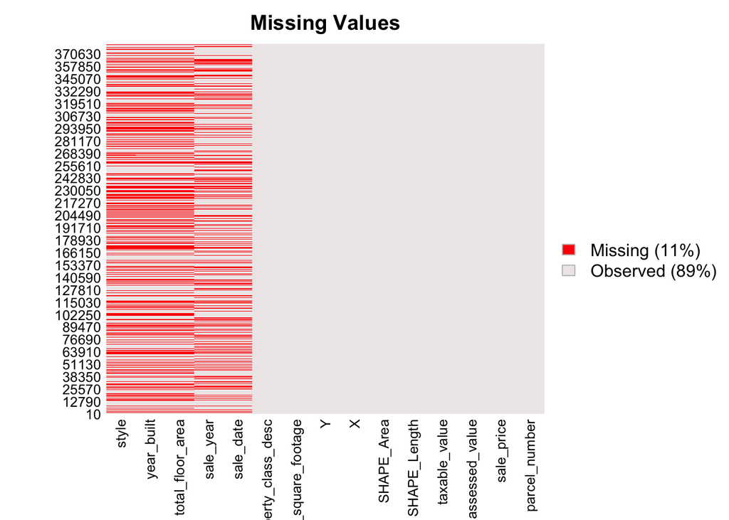

```
##
## Correlation method: 'pearson'
## Missing treated using: 'pairwise.complete.obs'
```

| term | assessed_value | taxable_value | total_floor_area | sale_price | total_square_footage | sale_year | year_built |
| --- | --- | --- | --- | --- | --- | --- | --- |
| assessed_value |  |  |  |  |  |  |  |
| taxable_value | .94 |  |  |  |  |  |  |
| total_floor_area | .56 | .54 |  |  |  |  |  |
| sale_price | .29 | .33 | .36 |  |  |  |  |
| total_square_footage | .07 | .09 | .29 | .04 |  |  |  |
| sale_year | .01 | .02 | .01 | .03 | .02 |  |  |
| year_built | -.00 | -.00 | -.02 | .00 | -.01 | .01 |  |

3. Foreclosures Data

```
## Rows: 135,010
## Columns: 20
## $ prop_addr      <chr> "439 E CONGRESS", "441 E CONGRESS", "2500 JOHN R", "231…
## $ prop_parcelnum <chr> "01000141.001", "01000141.002L", "01000588-91", "010005…
## $ `2002`         <dbl> NA, NA, NA, NA, NA, NA, NA, NA, NA, NA, NA, NA, NA, NA,…
## $ `2003`         <dbl> NA, NA, NA, NA, NA, NA, NA, NA, NA, NA, NA, NA, NA, NA,…
## $ `2004`         <dbl> NA, NA, NA, NA, NA, NA, NA, NA, NA, NA, NA, NA, NA, NA,…
## $ `2005`         <dbl> NA, NA, NA, NA, NA, NA, NA, NA, NA, NA, NA, NA, NA, NA,…
## $ `2006`         <dbl> NA, NA, NA, NA, NA, NA, NA, NA, NA, NA, NA, NA, NA, NA,…
## $ `2007`         <dbl> NA, NA, NA, NA, NA, NA, NA, NA, NA, NA, NA, NA, NA, NA,…
## $ `2008`         <dbl> NA, NA, NA, NA, NA, NA, NA, NA, NA, NA, NA, NA, NA, NA,…
## $ `2009`         <dbl> NA, NA, NA, NA, NA, NA, NA, NA, NA, NA, NA, NA, NA, NA,…
## $ `2010`         <dbl> NA, NA, NA, NA, NA, NA, 1, 1, NA, NA, NA, NA, NA, NA, N…
## $ `2011`         <dbl> NA, NA, 1, 1, 1, 1, NA, NA, 1, 1, 1, 1, 1, 1, 1, 1, 1, …
## $ `2012`         <dbl> NA, NA, NA, NA, NA, NA, NA, NA, NA, NA, NA, NA, NA, NA,…
## $ `2013`         <dbl> 1, 1, NA, NA, NA, NA, NA, NA, NA, NA, NA, NA, NA, NA, N…
## $ `2014`         <dbl> NA, NA, NA, NA, NA, NA, NA, NA, NA, NA, NA, NA, NA, NA,…
## $ `2015`         <dbl> NA, NA, NA, NA, NA, NA, NA, NA, NA, NA, NA, NA, NA, NA,…
## $ `2016`         <dbl> NA, NA, NA, NA, NA, NA, NA, NA, NA, NA, NA, NA, NA, NA,…
## $ `2017`         <dbl> NA, NA, NA, NA, NA, NA, NA, NA, NA, NA, NA, NA, NA, NA,…
## $ `2018`         <dbl> NA, NA, NA, NA, NA, NA, NA, NA, NA, NA, NA, NA, NA, NA,…
## $ `2019`         <dbl> NA, NA, NA, NA, NA, NA, NA, NA, NA, NA, NA, NA, NA, NA,…
```

Plot total foreclosures by year

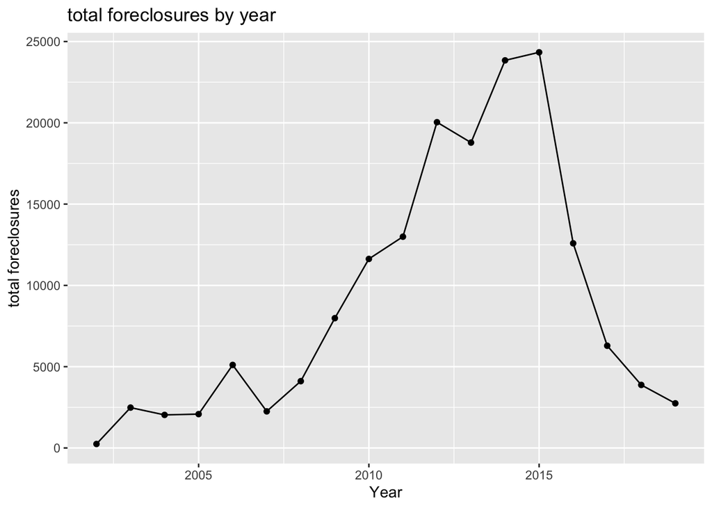

4. Assessments Data

```
## Rows: 3,874,582
## Columns: 5
## $ PARCELNO      <chr> "04990185.05", "08007238.", "08007253.003L", "08007253.0…
## $ propclass     <dbl> 401, 401, 401, 401, 401, 401, 401, 401, 401, 401, 401, 4…
## $ ASSESSEDVALUE <dbl> 0, 44510, 2997, 3040, 4871, 6162, 5621, 2538, 5704, 3330…
## $ TAXABLEVALUE  <dbl> 0, 9166, 2997, 3040, 4871, 6162, 5621, 2538, 5704, 3330,…
## $ year          <dbl> 2011, 2011, 2011, 2011, 2011, 2011, 2011, 2011, 2011, 20…
```

```
##    PARCELNO           propclass     ASSESSEDVALUE      TAXABLEVALUE
##  Length:3874582     Min.   :401.0   Min.   :      0   Min.   :      0
##  Class :character   1st Qu.:401.0   1st Qu.:    400   1st Qu.:    318
##  Mode  :character   Median :401.0   Median :   9900   Median :   7882
##                     Mean   :408.2   Mean   :  12588   Mean   :   9842
##                     3rd Qu.:401.0   3rd Qu.:  17443   3rd Qu.:  14168
##                     Max.   :483.0   Max.   :1736600   Max.   :1392600
##       year
##  Min.   :2011
##  1st Qu.:2014
##  Median :2017
##  Mean   :2016
##  3rd Qu.:2019
##  Max.   :2022
```

```
## [1] 0
```

Plot average assessed value by year

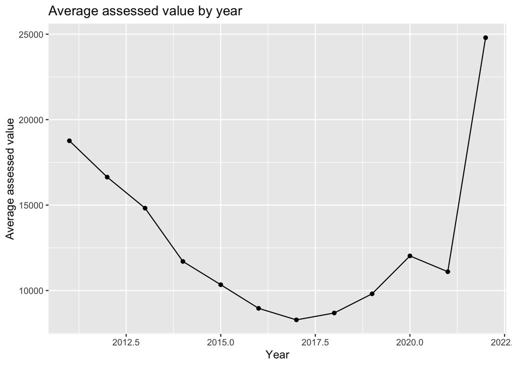

Section B: Use cmfproperty to conduct a sales ratio study across the relevant time period. Note that cmfproperty is designed to produce Rmarkdown reports but use the documentation and insert relevant graphs/figures into your report. Look to make this reproducible since you’ll need these methods to analyze your assessment model later on. Detroit has many sales which are not arm’s length (sold at fair market value) so some sales should be excluded, but which ones?

```
## [1] "Filtered out non-arm's length transactions"
## [1] "Inflation adjusted to 2020"
```

Create the master dataset for regression Merge data and check correlations

```
##
##  2011  2012  2013  2014  2015  2016  2017  2018  2019  2020
## 19854 24480 25955 41359 36765 29524 29347 29956 33025  6285
```

```
##
##   2002   2003   2004   2005   2006   2007   2008   2009   2010   2011   2012
## 134992 134992 134992 134992 134992 134992 134992 134992 134992 134992 134992
##   2013   2014   2015   2016   2017   2018   2019
## 134992 134992 134992 134992 134992 134992 134992
```

Check correlations

```
## Rows: 276,550
## Columns: 24
## $ parcel_num           <chr> "01000557.", "01000558.", "01000595.001", "010005…
## $ sale_year            <dbl> 2013, 2013, 2017, 2017, 2015, 2012, 2014, 2013, 2…
## $ sale_date.x          <date> 2013-11-07, 2013-11-07, 2017-06-21, 2017-06-21, …
## $ sale_price.x         <dbl> 29000, 29000, 1000000, 0, 5114, 148500, 100, 2025…
## $ grantor              <chr> "CITY OF DETROIT-P&DD", "CITY OF DETROIT-P&DD", "…
## $ grantee              <chr> "ROSS-GARDNER, MONA", "ROSS-GARDNER, MONA", "GERS…
## $ sale_terms           <chr> "MULTI PARCEL SALE", "MULTI PARCEL SALE", "NOT AR…
## $ ecf                  <chr> "4130A", "C04", "CNDOB", "CNDOB", "CNDOE", "NZH37…
## $ property_c           <dbl> 401, 401, 403, 403, 403, 401, 403, 403, 403, 403,…
## $ propclass            <dbl> 401, NA, 403, 403, 403, 401, 403, 403, 401, 401, …
## $ ASSESSEDVALUE        <dbl> 0, NA, 7800, 7800, 57200, 21063, 8784, 8784, 8210…
## $ TAXABLEVALUE         <dbl> 0, NA, 7800, 7800, 5797, 20549, 8784, 8784, 8210,…
## $ foreclosure          <dbl> 0, 0, 0, 0, 0, 0, 0, 0, 0, 0, 0, 0, 0, 0, 0, 0, 0…
## $ total_square_footage <dbl> 3023, 6608, NA, NA, NA, 6621, NA, 0, 0, 0, NA, NA…
## $ total_floor_area     <int> NA, NA, NA, NA, NA, 4984, NA, 2333, 2333, 2333, N…
## $ style                <chr> NA, NA, NA, NA, NA, "SINGLE FAMILY", NA, "APT FLA…
## $ property_class_desc  <chr> "COMMERCIAL VACANT", "COMMERCIAL VACANT", NA, NA,…
## $ year_built           <int> NA, NA, NA, NA, NA, 1900, NA, 1890, 1890, 1890, N…
## $ assessed_value       <dbl> 76100, 151300, NA, NA, NA, 228600, NA, 381400, 37…
## $ taxable_value        <dbl> 209, 11017, NA, NA, NA, 19020, NA, 8659, 5092, 50…
## $ SHAPE_Length         <dbl> 0.0008343630, 0.0011127726, NA, NA, NA, 0.0012836…
## $ SHAPE_Area           <dbl> 3.752554e-08, 7.510873e-08, NA, NA, NA, 6.752486e…
## $ X                    <dbl> -83.04857, -83.04837, NA, NA, NA, -83.05094, NA, …
## $ Y                    <dbl> 42.34256, 42.34263, NA, NA, NA, 42.34270, NA, 42.…
```

```
##                         sale_year sale_price.x ASSESSEDVALUE TAXABLEVALUE
## sale_year             1.000000000   0.04650988    -0.2733572   -0.3362837
## sale_price.x          0.046509883   1.00000000     0.1471346    0.1060158
## ASSESSEDVALUE        -0.273357237   0.14713463     1.0000000    0.9212701
## TAXABLEVALUE         -0.336283657   0.10601578     0.9212701    1.0000000
## total_square_footage -0.004211942   0.05977050     0.2259290    0.2510271
## total_floor_area     -0.006213840   0.22678231     0.2973724    0.2424775
##                      total_square_footage total_floor_area
## sale_year                    -0.004211942      -0.00621384
## sale_price.x                  0.059770499       0.22678231
## ASSESSEDVALUE                 0.225929046       0.29737243
## TAXABLEVALUE                  0.251027113       0.24247746
## total_square_footage          1.000000000       0.19232182
## total_floor_area              0.192321818       1.00000000
```

Plot the gap between sale price and assessed value by year

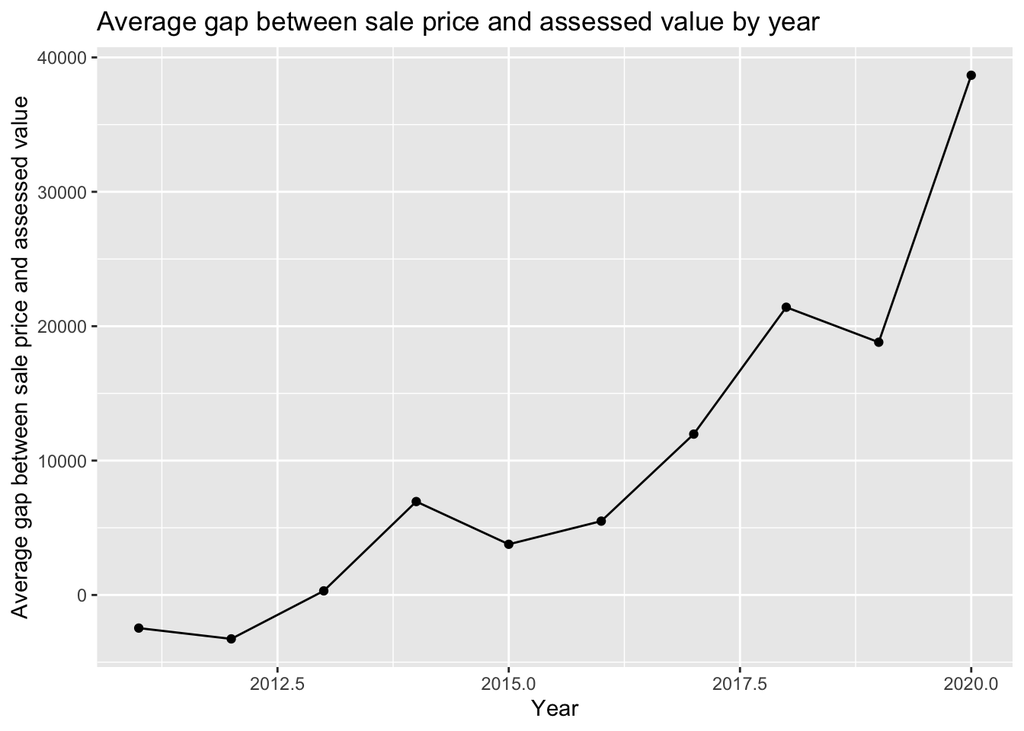

Plot the gap between sale price and assessed value by sale price

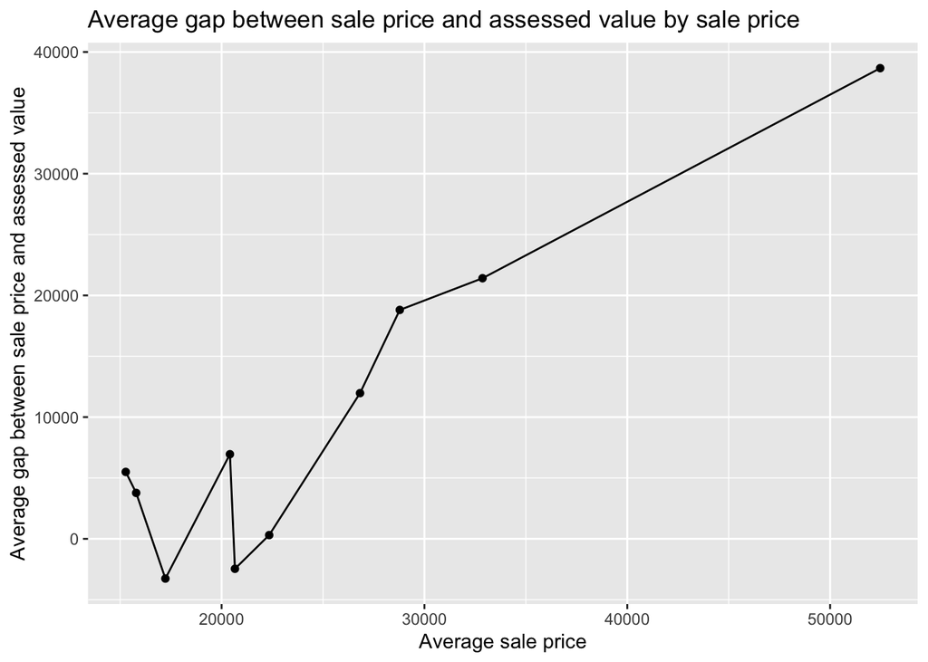

Section C: Explore trends and relationships with property sales using simple regressions Create a simple regression model including all possible parameters

```
## Rows: 276,550
## Columns: 24
## $ parcel_num           <chr> "01000557.", "01000558.", "01000595.001", "010005…
## $ sale_year            <dbl> 2013, 2013, 2017, 2017, 2015, 2012, 2014, 2013, 2…
## $ sale_date.x          <date> 2013-11-07, 2013-11-07, 2017-06-21, 2017-06-21, …
## $ sale_price.x         <dbl> 29000, 29000, 1000000, 0, 5114, 148500, 100, 2025…
## $ grantor              <chr> "CITY OF DETROIT-P&DD", "CITY OF DETROIT-P&DD", "…
## $ grantee              <chr> "ROSS-GARDNER, MONA", "ROSS-GARDNER, MONA", "GERS…
## $ sale_terms           <chr> "MULTI PARCEL SALE", "MULTI PARCEL SALE", "NOT AR…
## $ ecf                  <chr> "4130A", "C04", "CNDOB", "CNDOB", "CNDOE", "NZH37…
## $ property_c           <dbl> 401, 401, 403, 403, 403, 401, 403, 403, 403, 403,…
## $ propclass            <dbl> 401, NA, 403, 403, 403, 401, 403, 403, 401, 401, …
## $ ASSESSEDVALUE        <dbl> 0, NA, 7800, 7800, 57200, 21063, 8784, 8784, 8210…
## $ TAXABLEVALUE         <dbl> 0, NA, 7800, 7800, 5797, 20549, 8784, 8784, 8210,…
## $ foreclosure          <dbl> 0, 0, 0, 0, 0, 0, 0, 0, 0, 0, 0, 0, 0, 0, 0, 0, 0…
## $ total_square_footage <dbl> 3023, 6608, NA, NA, NA, 6621, NA, 0, 0, 0, NA, NA…
## $ total_floor_area     <int> NA, NA, NA, NA, NA, 4984, NA, 2333, 2333, 2333, N…
## $ style                <chr> NA, NA, NA, NA, NA, "SINGLE FAMILY", NA, "APT FLA…
## $ property_class_desc  <chr> "COMMERCIAL VACANT", "COMMERCIAL VACANT", NA, NA,…
## $ year_built           <int> NA, NA, NA, NA, NA, 1900, NA, 1890, 1890, 1890, N…
## $ assessed_value       <dbl> 76100, 151300, NA, NA, NA, 228600, NA, 381400, 37…
## $ taxable_value        <dbl> 209, 11017, NA, NA, NA, 19020, NA, 8659, 5092, 50…
## $ SHAPE_Length         <dbl> 0.0008343630, 0.0011127726, NA, NA, NA, 0.0012836…
## $ SHAPE_Area           <dbl> 3.752554e-08, 7.510873e-08, NA, NA, NA, 6.752486e…
## $ X                    <dbl> -83.04857, -83.04837, NA, NA, NA, -83.05094, NA, …
## $ Y                    <dbl> 42.34256, 42.34263, NA, NA, NA, 42.34270, NA, 42.…
```

```
##
## Call:
## lm(formula = sale_price.x ~ ASSESSEDVALUE + as.factor(propclass) +
##     sale_year + TAXABLEVALUE + foreclosure + total_square_footage +
##     total_floor_area + style + year_built, data = Sale_Merged)
##
## Residuals:
##      Min       1Q   Median       3Q      Max
##  -790755   -16721    -6512     8178 11009556
##
## Coefficients:
##                                             Estimate Std. Error t value
## (Intercept)                               -7.425e+06  1.897e+05 -39.137
## ASSESSEDVALUE                              1.330e+00  4.375e-02  30.404
## as.factor(propclass)402                    3.003e+04  3.196e+03   9.398
## as.factor(propclass)403                    7.138e+04  4.766e+03  14.976
## as.factor(propclass)404                    1.188e+05  5.486e+03  21.665
## as.factor(propclass)461                    1.147e+04  5.948e+03   1.929
## as.factor(propclass)465                    1.218e+04  5.310e+03   2.294
## as.factor(propclass)483                   -2.992e+05  4.807e+04  -6.224
## sale_year                                  3.679e+03  9.416e+01  39.067
## TAXABLEVALUE                              -4.947e-01  5.309e-02  -9.317
## foreclosure                               -1.426e+04  1.134e+03 -12.573
## total_square_footage                       1.351e+00  1.457e-01   9.279
## total_floor_area                           1.424e+01  5.932e-01  24.008
## styleAPT FLAT GARDEN                      -2.492e+04  6.133e+03  -4.063
## styleAPT HIGH RISE                         6.118e+04  6.251e+03   9.786
## styleBars (Taverns)                       -8.271e+04  6.428e+04  -1.287
## styleCARRIAGE HOUSE                        3.290e+04  1.544e+04   2.131
## styleDUPLEX                               -9.493e+03  4.437e+03  -2.139
## styleFOUR FAMILY                          -3.240e+04  2.632e+04  -1.231
## styleGARAGE/SHED                           2.469e+04  7.907e+03   3.122
## styleINCOME BUNGALOW                      -1.631e+04  3.581e+03  -4.555
## styleLARGE FLATS                          -2.643e+04  3.850e+03  -6.865
## styleLOFT APT WALKUP                       3.201e+04  7.327e+03   4.369
## styleMULTI DWELLING                       -1.645e+04  4.510e+03  -3.647
## styleMultiple Residences                   4.234e+05  6.415e+04   6.600
## styleROW HOUSE                            -8.659e+03  6.144e+03  -1.409
## styleSchools - Technical Trades Buildings -1.290e+05  6.509e+04  -1.983
## styleSheds - Equipment 4 Wall Building     1.086e+05  4.535e+04   2.394
```

[output cut: 27 more lines]

```
## styleMULTI DWELLING                       0.000266 ***
## styleMultiple Residences                  4.14e-11 ***
## styleROW HOUSE                            0.158736
## styleSchools - Technical Trades Buildings 0.047419 *
## styleSheds - Equipment 4 Wall Building    0.016659 *
## styleSINGLE FAMILY                        0.000494 ***
## styleTWO FAMILY FLAT                       < 2e-16 ***
## year_built                                0.331459
## ---
## Signif. codes:  0 '***' 0.001 '**' 0.01 '*' 0.05 '.' 0.1 ' ' 1
##
## Residual standard error: 64050 on 72534 degrees of freedom
##   (203985 observations deleted due to missingness)
## Multiple R-squared:  0.1351, Adjusted R-squared:  0.1347
## F-statistic: 377.6 on 30 and 72534 DF,  p-value: < 2.2e-16
```

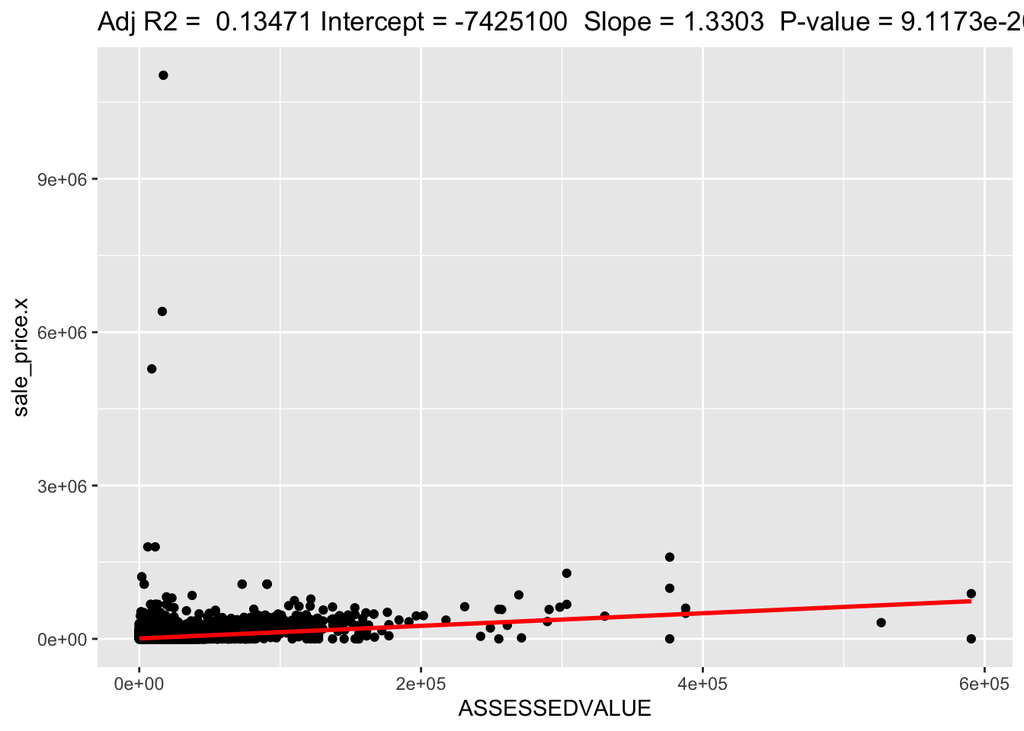

Create a simple regression model including all numeric possible parameters

```
##
## Call:
## lm(formula = sale_price.x ~ ASSESSEDVALUE + sale_year + TAXABLEVALUE +
##     foreclosure + total_square_footage + total_floor_area + year_built,
##     data = Sale_Merged)
##
## Residuals:
##      Min       1Q   Median       3Q      Max
##  -719734   -18444    -8125     7718 11004581
##
## Coefficients:
##                        Estimate Std. Error t value Pr(>|t|)
## (Intercept)          -7.598e+06  1.933e+05 -39.313   <2e-16 ***
## ASSESSEDVALUE         1.808e+00  4.354e-02  41.524   <2e-16 ***
## sale_year             3.764e+03  9.593e+01  39.238   <2e-16 ***
## TAXABLEVALUE         -6.950e-01  5.355e-02 -12.978   <2e-16 ***
## foreclosure          -1.614e+04  1.161e+03 -13.898   <2e-16 ***
## total_square_footage -3.222e-01  1.302e-01  -2.474   0.0133 *
## total_floor_area      9.223e+00  3.917e-01  23.548   <2e-16 ***
## year_built            6.337e+00  4.279e+00   1.481   0.1387
## ---
## Signif. codes:  0 '***' 0.001 '**' 0.01 '*' 0.05 '.' 0.1 ' ' 1
##
## Residual standard error: 65590 on 72559 degrees of freedom
##   (203983 observations deleted due to missingness)
## Multiple R-squared:  0.09286,    Adjusted R-squared:  0.09277
## F-statistic:  1061 on 7 and 72559 DF,  p-value: < 2.2e-16
```

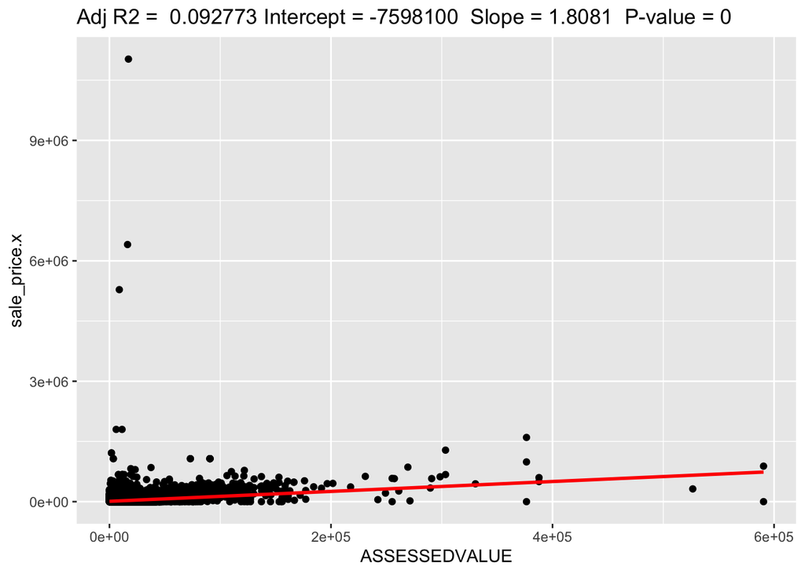

Create a simple regression model including parameters with significant result

```
##
## Call:
## lm(formula = sale_price.x ~ ASSESSEDVALUE + as.factor(propclass) +
##     sale_year + TAXABLEVALUE + foreclosure + total_square_footage +
##     total_floor_area, data = Sale_Merged)
##
## Residuals:
##      Min       1Q   Median       3Q      Max
##  -698953   -16966    -7024     8051 11008098
##
## Coefficients:
##                           Estimate Std. Error t value Pr(>|t|)
## (Intercept)             -7.521e+06  1.901e+05 -39.574  < 2e-16 ***
## ASSESSEDVALUE            1.452e+00  4.342e-02  33.434  < 2e-16 ***
## as.factor(propclass)402  4.234e+04  3.113e+03  13.603  < 2e-16 ***
## as.factor(propclass)403  8.955e+04  1.990e+03  44.990  < 2e-16 ***
## as.factor(propclass)404  1.273e+05  5.482e+03  23.220  < 2e-16 ***
## as.factor(propclass)461  1.502e+04  5.971e+03   2.516  0.01188 *
## as.factor(propclass)465  1.283e+04  5.335e+03   2.405  0.01616 *
## as.factor(propclass)483 -1.532e+05  4.699e+04  -3.260  0.00112 **
## sale_year                3.730e+03  9.427e+01  39.563  < 2e-16 ***
## TAXABLEVALUE            -5.250e-01  5.297e-02  -9.911  < 2e-16 ***
## foreclosure             -1.480e+04  1.140e+03 -12.988  < 2e-16 ***
## total_square_footage     1.417e+00  1.405e-01  10.086  < 2e-16 ***
## total_floor_area         7.021e+00  3.902e-01  17.991  < 2e-16 ***
## ---
## Signif. codes:  0 '***' 0.001 '**' 0.01 '*' 0.05 '.' 0.1 ' ' 1
##
## Residual standard error: 64360 on 72554 degrees of freedom
##   (203983 observations deleted due to missingness)
## Multiple R-squared:  0.1266, Adjusted R-squared:  0.1265
## F-statistic: 876.8 on 12 and 72554 DF,  p-value: < 2.2e-16
```

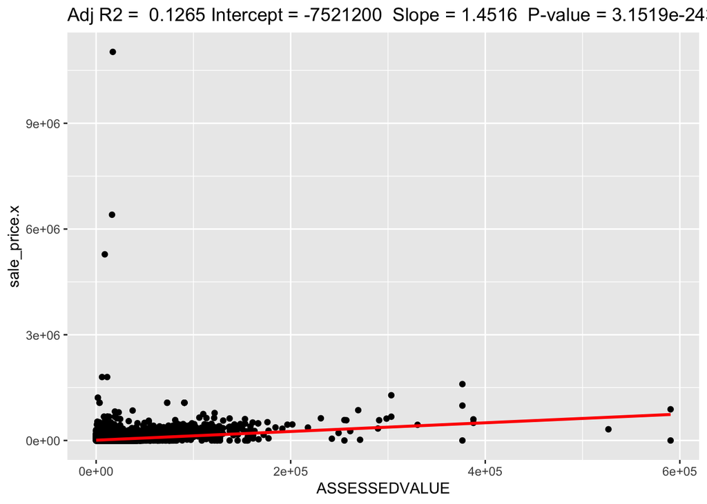

Drop outlier and create a simple regression model including parameters with significant result

```
##
## Call:
## lm(formula = sale_price.x ~ ASSESSEDVALUE + as.factor(propclass) +
##     sale_year + TAXABLEVALUE + foreclosure + total_square_footage +
##     total_floor_area, data = Sale_Merged)
##
## Residuals:
##     Min      1Q  Median      3Q     Max
## -699484  -16605   -6650    8344 1705919
##
## Coefficients:
##                           Estimate Std. Error t value Pr(>|t|)
## (Intercept)             -7.634e+06  1.154e+05 -66.130  < 2e-16 ***
## ASSESSEDVALUE            1.461e+00  2.637e-02  55.417  < 2e-16 ***
## as.factor(propclass)402  4.258e+04  1.891e+03  22.524  < 2e-16 ***
## as.factor(propclass)403  8.958e+04  1.209e+03  74.095  < 2e-16 ***
## as.factor(propclass)404  1.273e+05  3.330e+03  38.232  < 2e-16 ***
## as.factor(propclass)461  1.535e+04  3.627e+03   4.233 2.31e-05 ***
## as.factor(propclass)465  1.312e+04  3.240e+03   4.049 5.16e-05 ***
## as.factor(propclass)483 -1.538e+05  2.854e+04  -5.387 7.17e-08 ***
## sale_year                3.786e+03  5.726e+01  66.108  < 2e-16 ***
## TAXABLEVALUE            -5.337e-01  3.217e-02 -16.588  < 2e-16 ***
## foreclosure             -1.437e+04  6.922e+02 -20.763  < 2e-16 ***
## total_square_footage     1.364e+00  8.536e-02  15.982  < 2e-16 ***
## total_floor_area         7.262e+00  2.370e-01  30.638  < 2e-16 ***
## ---
## Signif. codes:  0 '***' 0.001 '**' 0.01 '*' 0.05 '.' 0.1 ' ' 1
##
## Residual standard error: 39100 on 72551 degrees of freedom
##   (203968 observations deleted due to missingness)
## Multiple R-squared:  0.2843, Adjusted R-squared:  0.2842
## F-statistic:  2401 on 12 and 72551 DF,  p-value: < 2.2e-16
```

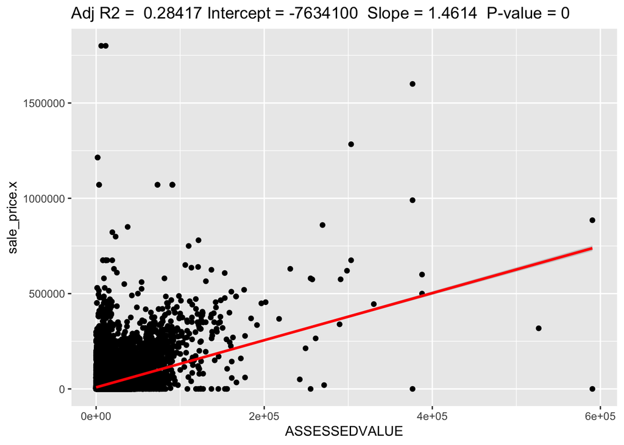

Section D: Explore trends and relationships with foreclosures using simple regressions Create a simple linear regression model including all possible parameters

```
##
## Call:
## lm(formula = foreclosure ~ sale_price.x + ASSESSEDVALUE + as.factor(propclass) +
##     sale_year + TAXABLEVALUE + total_square_footage + total_floor_area +
##     style + year_built, data = Sale_Merged)
##
## Residuals:
##      Min       1Q   Median       3Q      Max
## -0.48791 -0.06723 -0.04512 -0.02330  1.09195
##
## Coefficients:
##                                             Estimate Std. Error t value
## (Intercept)                                1.417e+01  6.353e-01  22.296
## sale_price.x                              -4.065e-07  2.007e-08 -20.249
## ASSESSEDVALUE                             -6.466e-08  1.453e-07  -0.445
## as.factor(propclass)402                   -1.512e-02  1.045e-02  -1.447
## as.factor(propclass)403                    8.780e-03  1.562e-02   0.562
## as.factor(propclass)404                    3.971e-02  1.806e-02   2.198
## as.factor(propclass)461                   -2.742e-02  1.941e-02  -1.413
## as.factor(propclass)465                   -2.366e-02  1.733e-02  -1.365
## as.factor(propclass)483                    5.362e-01  1.570e-01   3.415
## sale_year                                 -7.007e-03  3.153e-04 -22.222
## TAXABLEVALUE                               4.423e-07  1.736e-07   2.548
## total_square_footage                       2.774e-07  4.761e-07   0.583
## total_floor_area                          -2.395e-06  1.958e-06  -1.223
## styleAPT FLAT GARDEN                       6.162e-03  2.002e-02   0.308
## styleAPT HIGH RISE                        -8.762e-03  2.044e-02  -0.429
## styleBars (Taverns)                       -4.415e-02  2.098e-01  -0.210
## styleCARRIAGE HOUSE                        4.633e-02  5.038e-02   0.920
## styleDUPLEX                                7.668e-03  1.448e-02   0.529
## styleFOUR FAMILY                          -6.082e-03  8.590e-02  -0.071
## styleGARAGE/SHED                          -6.073e-02  2.581e-02  -2.353
## styleINCOME BUNGALOW                      -1.152e-03  1.169e-02  -0.099
## styleLARGE FLATS                           6.596e-03  1.258e-02   0.524
## styleLOFT APT WALKUP                      -1.433e-02  2.392e-02  -0.599
## styleMULTI DWELLING                       -1.145e-02  1.472e-02  -0.778
## styleMultiple Residences                   1.847e-01  2.095e-01   0.882
## styleROW HOUSE                            -2.961e-02  2.005e-02  -1.477
## styleSchools - Technical Trades Buildings  3.192e-02  2.124e-01   0.150
## styleSheds - Equipment 4 Wall Building    -4.721e-04  1.480e-01  -0.003
```

[output cut: 27 more lines]

```
## styleMULTI DWELLING                       0.436822
## styleMultiple Residences                  0.378037
## styleROW HOUSE                            0.139758
## styleSchools - Technical Trades Buildings 0.880551
## styleSheds - Equipment 4 Wall Building    0.997456
## styleSINGLE FAMILY                        0.437809
## styleTWO FAMILY FLAT                      0.606509
## year_built                                0.612897
## ---
## Signif. codes:  0 '***' 0.001 '**' 0.01 '*' 0.05 '.' 0.1 ' ' 1
##
## Residual standard error: 0.2091 on 72531 degrees of freedom
##   (203970 observations deleted due to missingness)
## Multiple R-squared:  0.01997,    Adjusted R-squared:  0.01957
## F-statistic: 49.27 on 30 and 72531 DF,  p-value: < 2.2e-16
```

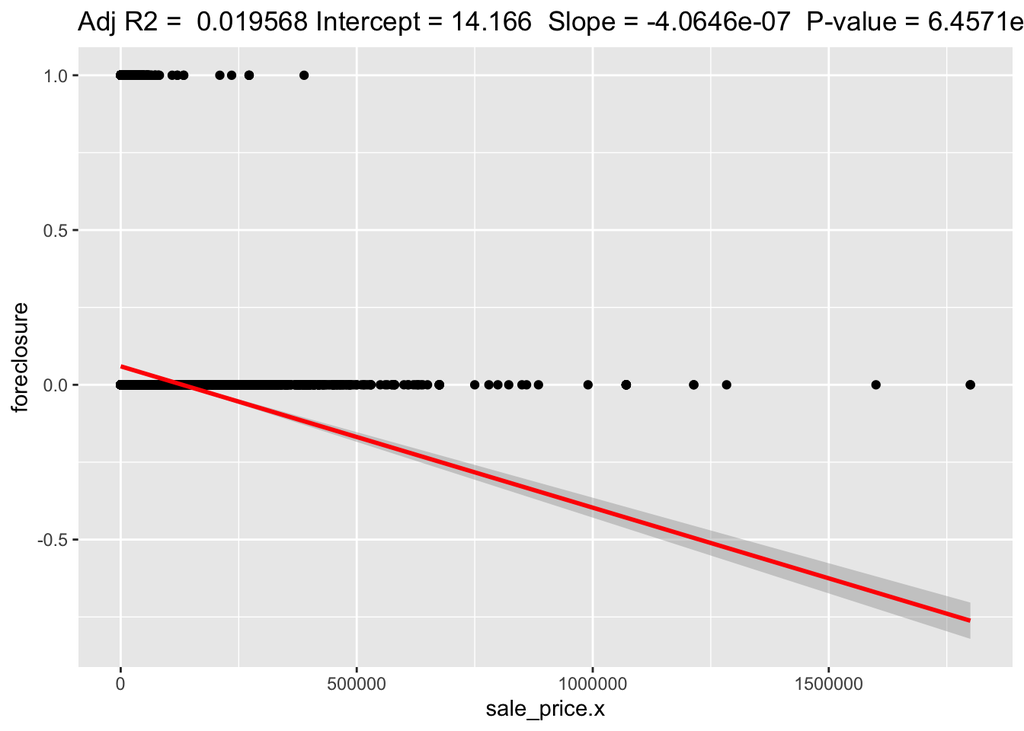

Linear regression is not suitable

Change to logistic regression with all possible parameters

```
##
## Call:
## glm(formula = foreclosure ~ sale_price.x + ASSESSEDVALUE + as.factor(propclass) +
##     sale_year + TAXABLEVALUE + total_square_footage + total_floor_area +
##     style + year_built, family = "binomial", data = Sale_Merged)
##
## Deviance Residuals:
##     Min       1Q   Median       3Q      Max
## -1.9035  -0.3870  -0.2463  -0.1104   7.0433
##
## Coefficients:
##                                             Estimate Std. Error z value
## (Intercept)                                2.475e+02  1.733e+01  14.286
## sale_price.x                              -5.847e-05  1.884e-06 -31.026
## ASSESSEDVALUE                             -7.251e-05  7.942e-06  -9.131
## as.factor(propclass)402                   -3.748e-01  3.686e-01  -1.017
## as.factor(propclass)403                    1.833e-01  5.736e-01   0.320
## as.factor(propclass)404                    4.915e-01  1.072e+00   0.458
## as.factor(propclass)461                   -1.168e+00  7.176e-01  -1.627
## as.factor(propclass)465                   -1.304e+00  1.008e+00  -1.294
## as.factor(propclass)483                    6.952e+00  9.508e+00   0.731
## sale_year                                 -1.246e-01  8.609e-03 -14.473
## TAXABLEVALUE                               7.956e-05  7.993e-06   9.953
## total_square_footage                       1.591e-05  1.116e-05   1.425
## total_floor_area                           3.454e-05  5.057e-05   0.683
## styleAPT FLAT GARDEN                       1.806e-01  6.560e-01   0.275
## styleAPT HIGH RISE                        -1.152e+01  9.022e+01  -0.128
## styleBars (Taverns)                       -1.216e+01  2.400e+03  -0.005
## styleCARRIAGE HOUSE                       -1.190e+01  3.285e+02  -0.036
## styleDUPLEX                                2.535e-01  3.265e-01   0.777
## styleFOUR FAMILY                          -1.097e+01  8.553e+02  -0.013
## styleGARAGE/SHED                          -1.365e+01  2.616e+02  -0.052
## styleINCOME BUNGALOW                      -1.600e-01  2.599e-01  -0.616
## styleLARGE FLATS                           4.888e-02  2.912e-01   0.168
## styleLOFT APT WALKUP                      -4.273e-01  1.180e+00  -0.362
## styleMULTI DWELLING                       -6.242e-01  4.276e-01  -1.460
## styleMultiple Residences                   1.909e+01  2.400e+03   0.008
## styleROW HOUSE                            -1.338e+00  8.991e-01  -1.488
## styleSchools - Technical Trades Buildings -6.547e+00  2.400e+03  -0.003
## styleSheds - Equipment 4 Wall Building    -6.260e+00  1.697e+03  -0.004
```

[output cut: 31 more lines]

```
## styleSheds - Equipment 4 Wall Building       0.997
## styleSINGLE FAMILY                           0.374
## styleTWO FAMILY FLAT                         0.871
## year_built                                   0.318
## ---
## Signif. codes:  0 '***' 0.001 '**' 0.01 '*' 0.05 '.' 0.1 ' ' 1
##
## (Dispersion parameter for binomial family taken to be 1)
##
##     Null deviance: 27408  on 72561  degrees of freedom
## Residual deviance: 24374  on 72531  degrees of freedom
##   (203970 observations deleted due to missingness)
## AIC: 24436
##
## Number of Fisher Scoring iterations: 15
```

Create a logistic regression with significant parameters

```
##
## Call:
## glm(formula = foreclosure ~ sale_price.x + ASSESSEDVALUE + sale_year +
##     TAXABLEVALUE, family = "binomial", data = Sale_Merged)
##
## Deviance Residuals:
##     Min       1Q   Median       3Q      Max
## -4.1154  -0.5628  -0.4734  -0.3552   4.7843
##
## Coefficients:
##                 Estimate Std. Error z value Pr(>|z|)
## (Intercept)    2.399e+02  5.459e+00   43.94   <2e-16 ***
## sale_price.x  -1.936e-05  3.867e-07  -50.07   <2e-16 ***
## ASSESSEDVALUE -2.293e-05  2.094e-06  -10.95   <2e-16 ***
## sale_year     -1.200e-01  2.708e-03  -44.30   <2e-16 ***
## TAXABLEVALUE   3.492e-05  2.225e-06   15.69   <2e-16 ***
## ---
## Signif. codes:  0 '***' 0.001 '**' 0.01 '*' 0.05 '.' 0.1 ' ' 1
##
## (Dispersion parameter for binomial family taken to be 1)
##
##     Null deviance: 198987  on 269446  degrees of freedom
## Residual deviance: 190549  on 269442  degrees of freedom
##   (7085 observations deleted due to missingness)
## AIC: 190559
##
## Number of Fisher Scoring iterations: 7
```

Plot Model_Foreclosure_3

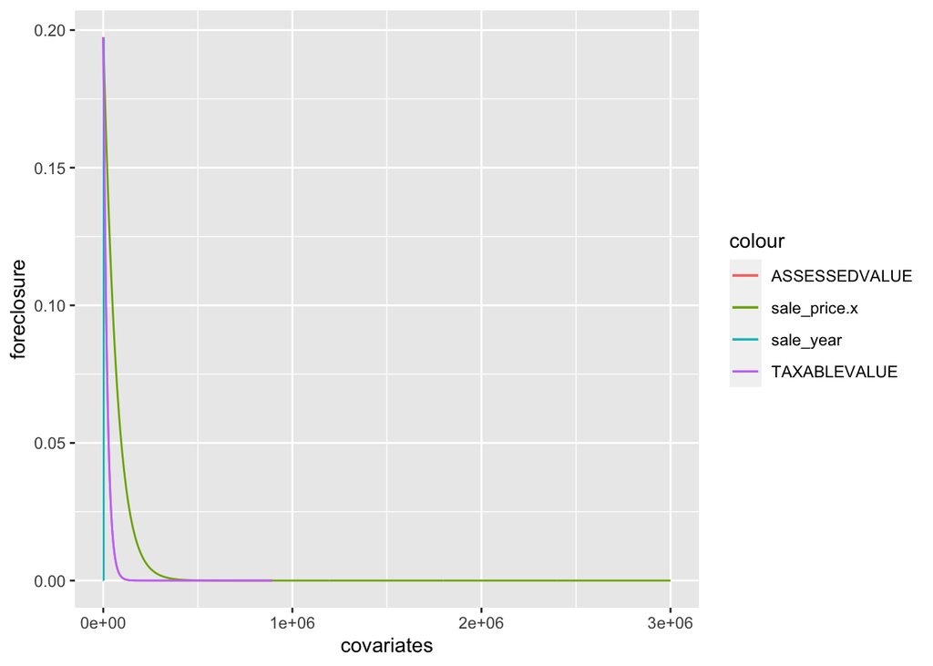

Create a lasso regression model including all numeric possible parameters Try to find a “best” model

```
##
## Call:
## lm(formula = sale_price.x ~ ASSESSEDVALUE + sale_year + TAXABLEVALUE +
##     foreclosure + total_square_footage + total_floor_area + year_built,
##     data = Sale_Merged)
##
## Residuals:
##     Min      1Q  Median      3Q     Max
## -721292  -18088   -7773    8037 1786894
##
## Coefficients:
##                        Estimate Std. Error t value Pr(>|t|)
## (Intercept)          -7.711e+06  1.211e+05 -63.681  < 2e-16 ***
## ASSESSEDVALUE         1.818e+00  2.728e-02  66.642  < 2e-16 ***
## sale_year             3.819e+03  6.010e+01  63.552  < 2e-16 ***
## TAXABLEVALUE         -7.037e-01  3.355e-02 -20.976  < 2e-16 ***
## foreclosure          -1.571e+04  7.274e+02 -21.598  < 2e-16 ***
## total_square_footage -3.750e-01  8.157e-02  -4.597 4.29e-06 ***
## total_floor_area      9.472e+00  2.454e-01  38.602  < 2e-16 ***
## year_built            6.754e+00  2.681e+00   2.519   0.0118 *
## ---
## Signif. codes:  0 '***' 0.001 '**' 0.01 '*' 0.05 '.' 0.1 ' ' 1
##
## Residual standard error: 41100 on 72556 degrees of freedom
##   (203968 observations deleted due to missingness)
## Multiple R-squared:  0.2091, Adjusted R-squared:  0.2091
## F-statistic:  2741 on 7 and 72556 DF,  p-value: < 2.2e-16
```

find optimal lambda value that minimizes test MSE

```
## [1] 28.0782
```

```
## 7 x 1 sparse Matrix of class "dgCMatrix"
##                                 s0
## (Intercept)          -7.980229e+06
## ASSESSEDVALUE         1.807472e+00
## TAXABLEVALUE         -6.871314e-01
## total_square_footage -3.632407e-01
## total_floor_area      9.484419e+00
## sale_year             3.953380e+03
## year_built            5.977534e+00
```